# Branching Out: Using Decision Trees to Inform Education Decisions

Supplemental Appendix

DRAFT

Data analysts can use this appendix to gain basic knowledge of programming in R and replicate the CART analysis presented through the Eduphonia example in the guide. The grey boxes contain annotated R programming code, and include a button in the upper left corner to copy code. The associated output is presented in blue boxes and figures.

## CART framework

CART analysis relies on a predictive algorithm that uses a model to identify the relationships between a set of characteristics and an outcome of interest. When conducting a CART analysis, work proceeds in three broad stages—preparing the data, developing the model, and analyzing the results (exhibit 1). This appendix describes each of these stages in detail.

**Exhibit 1. CART analysis processes by stage**

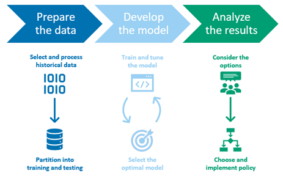

## Software requirements

To replicate the analyses described in this guide, users will need **R** (version 3.6 or above) and **RStudio**, along with a basic understanding of both. Users may need to consult other resources for assistance with the software. **R** is a programming language and free software environment for statistical computing and graphics supported by the R Foundation for Statistical Computing. You can download R from the [Comprehensive R Archive Network (CRAN)](https://cloud.r-project.org/). **RStudio** is an integrated development environment for R. You can download it directly from [RStudio](https://rstudio.com/products/rstudio/download/).

Several packages in R implement CART analysis. This example uses the `rpart` package, which is included in base R (exhibit 2). The `rpart` package implements CART analysis as described by Breiman and colleages (1984). See the *Recursive Partitioning* section of [CRAN Task View: Machine Learning & Statistical Learning](https://cran.r-project.org/web/views/MachineLearning.html) for the full list of related packages, as well as detailed helkp pages and vignettes. You can also find additional information through the `??package`, `?procedure`, and `vignette('package')` commands in R.

**Exhibit 2. Install and load R packages**

```r
# If these packages have not been installed previously, use install.packages()
# to install them before loading them for use in your work session.
install.packages("caret")
install.packages("rpart")
install.packages("rpart.plot")
install.packages("ROCR")
```

```r
# Load the packages.
library(caret)          # Functions to streamline model training and tuning processes
library(rpart)          # Implementation of CART analysis algorithm
library(rpart.plot)     # Procedure to plot the results of rpart
library(ROCR)           # Tool for creating curves of performance measures
```

## Stage 1: Prepare the data

**Prepare the data.** In the prepare the data stage, data analysts must obtain data for a prior cohort that contain the set of characteristics and outcome of interest; select data observations and variables to include in the analysis; process the data for use in the analysis, including cleaning the data, dealing with missing values, and transforming or creating new variables; and partition it into training data and testing data for use in separate parts of the analysis.

For demonstration purposes, this analysis uses publicly available data from the U.S. Department of Education’s [Early Childhood Longitudinal Study](https://nces.ed.gov/ecls/), Kindergarten Class of 1998/99 (ECLS-K), as the prior cohort. The ECLS-K data focus on children’s early school experiences. Our analysis sample follows ECLS-K students from kindergarten through middle school, linking data across time. The data are from the National Center for Education Statistics [Online Codebook](https://nces.ed.gov/OnlineCodebook/Session/Codebook/6c5af0be-772a-4cb8-9059-4297b831efef), which allows for selection of variables and access to documentation. Visit the [Inter-university Consortium for Political and Social Research](https://www.icpsr.umich.edu/web/ICPSR/studies/28023) for additional information.

The example presented in this appendix uses a dataset that has been cleaned and prepared for this analysis. To prepare the dataset, analysts selected variables of interest from among all of the variables available in the ECLS-K data; examined patterns of missingness in the data; and transformed the continuous outcome variable, a grade 3 mathematics test score, into a dichotomous variable that indicates whether or not each student scored Below Proficient (exhibit 2).

**Exhibit 2. Variable names and details of ECLS-K data**

| Variable | Variable details (ECLS-K variable name) |
| --- | --- |
| `MathARS` | Fall kindergarten mathematical thinking academic rating scale (T1RARSMA) |
| `LiteracyARS` | Fall kindergarten language and literacy academic rating scale (T1RARSLI) |
| `GeneralARS` | Fall kindergarten general knowledge academic rating scale (T1RARSGE) |
| `LetterRecog` | Fall kindergarten proficiency probability score for letter recognition (C1R4RPB1) |
| `BeginSounds` | Fall kindergarten proficiency probability score for beginning sounds (C1R4RPB2) |
| `EndSounds` | Fall kindergarten proficiency probability score for ending sounds (C1R4RPB3) |
| `SightWords` | Fall kindergarten proficiency probability score for sight words (C1R4RPB4) |
| `CountNumShp` | Fall kindergarten proficiency probability score for count, number, shape (C1R4MPB1) |
| `RelativeSize` | Fall kindergarten proficiency probability score for relative size (C1R4MPB2) |
| `OrdinalSeq` | Fall kindergarten proficiency probability score for ordinality, sequence (C1R4MPB3) |
| `AddSubtract` | Fall kindergarten proficiency probability score for add/subtract (C1R4MPB4) |
| `AtRisk` | Indicator of scoring Below Proficient on state math assessment at the end of grade 3 (C5R4MTSC) |

Users can access the dataset used in this guide here (exhibit 3).

**Exhibit 3. Load data and assign variables**

```r
# Use the load() command to read in the data.
load("../data/eclsk.rdata")     # Change the file name to access your data file.

# Create a copy of your data in mydata to allow you to use the remaining code more easily.
mydata <- eclsk         # Change the dataset name to access your data.

# Assign the outcome to depvar, the dependent variable.
depvar <- "AtRisk"      # Change the dependent variable to your outcome of interest.

# Define the set of independent variables for the analysis.
indepvar <- c(          # Change the independent variables to your characteristics.
  "LiteracyARS","MathARS","GeneralARS","LetterRecog","BeginSounds","EndSounds","SightWords",
  "CountNumShp","RelativeSize","OrdinalSeq","AddSubtract")

# Use dim() to show the dimensions of the data.
dim(mydata)
```

```
[1] 14374    12
```

After preparing the data and before any analysis takes place, users must partition the data for the prior cohort into training and testing data (exhibit 4). The CART analysis uses training data to train and tune the model in stage 2 and the testing data in stage 3 to evaluate the predictive accuracy of the final model created with the training data.

**Exhibit 4. Partition the data into training and testing data**

```r
# Use set.seed() to set the seed for R's random number generator. This is
# useful for creating sets of random numbers in order to reproduce and
# replicate analyses. The seed can be set to any value, but you will need
# to leave the seed unchanged to replicate the results in this appendix.
set.seed(101010)

# Use createDataPartition() to randomly select 80% of the data (p=.8), while
# maintaining the same proportion of Yes for the outcome (depvar) as in the
# full data. This only needs to be done once (times=1) and you do not need
# to print each of the observations (list=FALSE). You will need to use
# as.vector() to save the results as a vector for the next step.
train_index <- as.vector(createDataPartition(mydata[[depvar]],p=.8,list=FALSE,times=1))

# Assign the 80% of observations identified above to the training data and
# the remaining 20% of observations to the testing data.
mytrain <- mydata[train_index, ]
mytest <- mydata[-train_index, ]
```

## Stage 2: Develop the model

**Develop the model.** In the develop the model stage, the CART analysis runs an algorithm repeatedly as part of a training and tuning process to identify the optimal model. When training the model, the CART analysis runs the algorithm on the training data to generate a set of decision rules. In tuning the model, the data analyst changes the parameters of the algorithm and trains the model for each set of parameters to identify the optimal model. The CART analysis evaluates the model at multiple points. As the algorithm constructs the decision tree, it considers many possible ways to split the groups. In each step of the process, it identifies all of the possible splits, with each split based on a single variable. The algorithm then uses an internal metric to identify the split that leads to the greatest improvement in the predictive accuracy to identify the best way to split the data. Then the process repeats and the CART analysis again considers many possible ways to split the groups. The CART analysis will consider all of the variables when determining how to split the data. Because it only makes the best of all possible splits, CART may not use all of the variables included in the model in the resulting analysis or the final tree. The tuning process uses a different metric to evaluate the overall fit of the model from each training and select the optimal model.

To train and tune the CART analysis to determine the optimal model, users will use the `rpart` algorithm in the `caret` package, short for **C**lassification **a**nd **Re**gression **T**raining (exhibit 5).

The first command in the code defines a formula in R to use in each analysis. The formula specifies that the dependent variable (`depvar`) is a function of a set of independent variables (`indepvar`):

- Kindergarten measures of specific math knowledge (CountNumShp, RelativeSize, OrdinalSeq, and AddSubtract)
- Kindergarten measures of language knowledge (LetterRecog, BeginSounds, EndSounds, and SightWords)
- Kindergarten measures of broad knowledge (LiteracyARS, MathARS, and GeneralARS).

The CART analysis uses these independent variables to predict the indicator for scoring Below Proficient on the state math assessment at the end of grade 3 (AtRisk), which is specified as the dependent variable (see exhibit 3).

The next section of the code uses the `train` function in `caret` to run `rpart` on the training data. The function `trainControl` is where users specify the parameters for the `train` function:

- `Method`, `number`, and `repeats` provide specifications for the cross-validation
- `savePredictions` tells R to save the results from the analysis for use in the next phase
- `selectionFunction` tells R to use the one standard error rule
- `classProbs` and `summaryFunction` provide specifications related to the performance measures

The specifications for the `train` function include `tuneLength`, which specifies that the CART analysis should try 10 values of `cp`, and `metric`, which identifies receiver operating characteristic (`ROC`) as the performance measure to optimize. Therefore, at each of the 10 values of `cp`, the CART analysis runs the training process to find the optimal model and the associated value of the performance `metric`. Then, across all values of `cp`, the CART analysis uses the `selectionFunction` to choose the optimal model.

**Exhibit 5. Train and tune the CART analysis to determine the optimal model**

```r
# Set up the formula for the model in which the dependent variable is
# a function of the set of independent variables. Use paste() to create
# a summation of the variables in indepvar using + between each, and
# again to add depvar and the ~ symbol before them. Finally, use
# as.formula() to save the combination in myformula.
myformula <- as.formula(paste(depvar,paste(indepvar,collapse=" + "),sep=" ~ "))

# Use trainControl() to define parameters for train().
mycontrol <- trainControl(
  method = "repeatedcv",               # Repeated cross-validation
  number = 10,                         # Number of folds (k)
  repeats = 10,                        # Number of repeats (n) of cross-validation
  savePredictions = "final",           # Save predictions for best tuning parameters
  classProbs = TRUE,                   # Compute probabilities for each class
  selectionFunction = "oneSE",         # Select model within one standard error of best
  summaryFunction = twoClassSummary    # Provide ROC, sensitivity, and specificity
)

# Use caret's train() function to tune using cp and select using ROC.
mytree <- train(
  myformula,                           # Use the formula defined above
  data = mytrain,                      # Use the subset of data for training
  method = "rpart",                    # Use the rpart procedure for CART analysis
  trControl = mycontrol,               # Use the controls defined above
  tuneLength = 10,                     # Try 10 values of the complexity parameter (cp)
  metric = "ROC"                       # Use the ROC as the metric for choosing the model
)

# Look at the output from the CART analysis.
mytree
```

```
CART

11500 samples
   11 predictor
    2 classes: 'No', 'Yes'

No pre-processing
Resampling: Cross-Validated (10 fold, repeated 10 times)
Summary of sample sizes: 10350, 10350, 10350, 10350, 10349, 10350, ...
Resampling results across tuning parameters:

  cp           ROC        Sens       Spec
  0.001216968  0.8015215  0.9161765  0.4203375
  0.001390821  0.8027753  0.9158637  0.4225956
  0.001564673  0.8042040  0.9165479  0.4233228
  0.001738526  0.8045191  0.9169422  0.4231139
  0.002086231  0.8054273  0.9157826  0.4285714
  0.002433936  0.8061254  0.9155858  0.4310420
  0.004056560  0.7637101  0.9155052  0.4239251
  0.004520167  0.7332805  0.9183219  0.4125508
  0.015125174  0.7139931  0.8887995  0.4931895
  0.161682893  0.6091557  0.9268080  0.2915033

ROC was used to select the optimal model using  the one SE rule.
The final value used for the model was cp = 0.002433936.
```

Users can look at the nodes and decision rules of the optimal model (exhibit 6).

**Exhibit 6. Print the nodes and decision rules from the optimal model**

```r
# Print the nodes and decision rules from the optimal model.
mytree$finalModel
```

```
n= 11500

node), split, n, loss, yval, (yprob)
      * denotes terminal node

  1) root 11500 2876 No (0.74991304 0.25008696)
    2) RelativeSize>=0.2395 8795 1291 No (0.85321205 0.14678795)
      4) RelativeSize>=0.6465 5057  254 No (0.94977259 0.05022741) *
      5) RelativeSize< 0.6465 3738 1037 No (0.72257892 0.27742108)
       10) MathARS>=1.725 3395  874 No (0.74256259 0.25743741) *
       11) MathARS< 1.725 343  163 No (0.52478134 0.47521866)
         22) CountNumShp>=0.9575 226   87 No (0.61504425 0.38495575) *
         23) CountNumShp< 0.9575 117   41 Yes (0.35042735 0.64957265) *
    3) RelativeSize< 0.2395 2705 1120 Yes (0.41404806 0.58595194)
      6) CountNumShp>=0.7465 1808  903 Yes (0.49944690 0.50055310)
       12) CountNumShp>=0.9225 661  287 No (0.56580938 0.43419062) *
       13) CountNumShp< 0.9225 1147  529 Yes (0.46120314 0.53879686)
         26) MathARS>=1.555 970  466 Yes (0.48041237 0.51958763)
           52) LetterRecog>=0.1905 620  305 No (0.50806452 0.49193548)
            104) LetterRecog< 0.4045 189   75 No (0.60317460 0.39682540) *
            105) LetterRecog>=0.4045 431  201 Yes (0.46635731 0.53364269) *
           53) LetterRecog< 0.1905 350  151 Yes (0.43142857 0.56857143) *
         27) MathARS< 1.555 177   63 Yes (0.35593220 0.64406780) *
      7) CountNumShp< 0.7465 897  217 Yes (0.24191750 0.75808250) *
```

However, one of the main benefits of CART analysis is the ability to show information graphically (exhibit 7).

**Exhibit 7. Plot the nodes and decision rules from the optimal model**

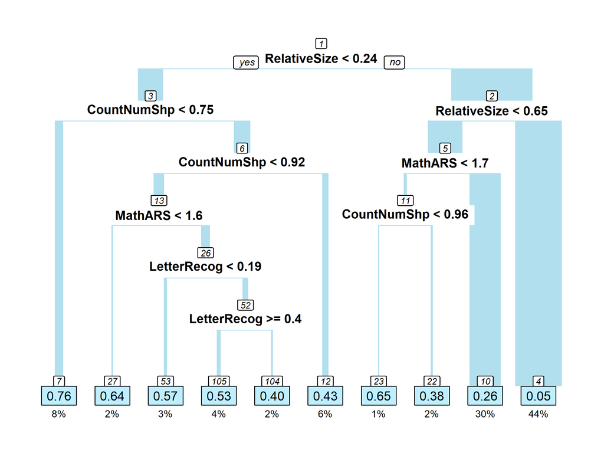

```r
# Plot the nodes and decision rules from the optimal model.
rpart.plot(
  mytree$finalModel,                   # The optimal model from the CART analysis
  box.palette = "lightblue1",          # Box color
  type = 0,                            # Draw labels for each split and node
  leaf.round = 0,                      # Do not use rounded terminal nodes
  nn = T,                              # Include node numbers
  branch.col = "lightblue2",           # Color of the branches
  branch.type = 5,                     # Branch width based on share of students
  extra = 107,                         # Show % in node at risk and % of all students
  xflip = T,                           # Flip the tree horizontally
  under = T,                           # Place overall percentage under leaf
  cex = 1                              # Size of text
)
```

## Stage 3: Analyze the results

**Analyze the results.** When analyzing the results, educators create a set of options derived from the final model, consider the implications of each option, select an option, and then implement the decision using the model on data for the current cohort of students.

In this step, users will assess the predictive accuracy by generating a ROC curve, which plots information about true positive and false positive rates to inform options for educators to consider (exhibit 8). First, using `predict`, the code generates predicted values for each student by applying the rules from the model above. Next, `performance` calculates the true positive and false positive rates in the testing data. Finally, the last section of code creates the ROC curve.

**Exhibit 8. Predict probabilities using the model and plot the ROC curve**

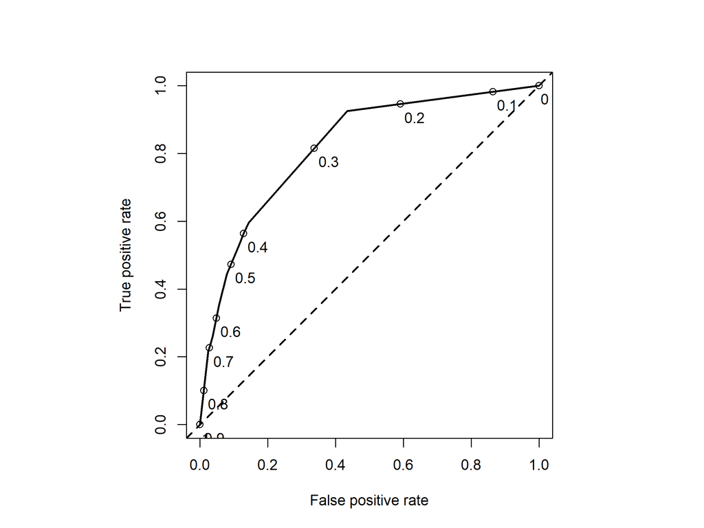

```r
# Use predict() to predict probabilities of scoring Below Proficient
# or not using the model from caret and save the at risk probability
# as the prediction.
pred <- predict(mytree$finalModel,mytest,type="prob")[,2]

# Use prediction() to transform the predictions and actual values
# into a format for use by performance(), which calculates the true
# positive and false positive rates.
perf <- performance(prediction(pred,mytest[[depvar]]),"tpr","fpr")

# Use par() to format the plotting area as a square. Then use plot()
# to plot the combinations of true positive and false positive rates
# and include labels for values of the probability threshold. Finally,
# use abline() to include a line for reference.
par(pty="s")
plot(perf,print.cutoffs.at=seq(0,1,by=0.1),text.adj=c(-0.2,1.7),lwd=2)
abline(0,1,lty=2,lwd=2)
```

The user can obtain the true positive rates (`tpr`) and false positive rates (`fpr`) from the ROC curve for the probability thresholds (`pth`) that correspond with each of the 10 terminal nodes above (exhibit 9).

**Exhibit 9. Extract results to inform options**

```r
# Extract the x, y, and alpha values from the points along the ROC curve.
rocpoints <- data.frame(pth=perf@alpha.values[[1]],tpr=perf@y.values[[1]],
                        fpr=perf@x.values[[1]])

# Print the values of the measures for each point along the ROC curve.
rocpoints
```

```
          pth       tpr        fpr
1         Inf 0.0000000 0.00000000
2  0.75808250 0.2158774 0.02365492
3  0.64957265 0.2353760 0.03014842
4  0.64406780 0.2618384 0.03756957
5  0.56857143 0.3509749 0.05565863
6  0.53364269 0.4442897 0.07931354
7  0.43419062 0.5292479 0.11456401
8  0.39682540 0.5668524 0.12940631
9  0.38495575 0.5961003 0.14378479
10 0.25743741 0.9247911 0.43367347
11 0.05022741 1.0000000 1.00000000
```

Next, the user will use the combination of rates from rows of the output above to determine the implications of providing the intervention to different groups of students (exhibit 10).

**Exhibit 10. Implications of providing the intervention to different groups of students**

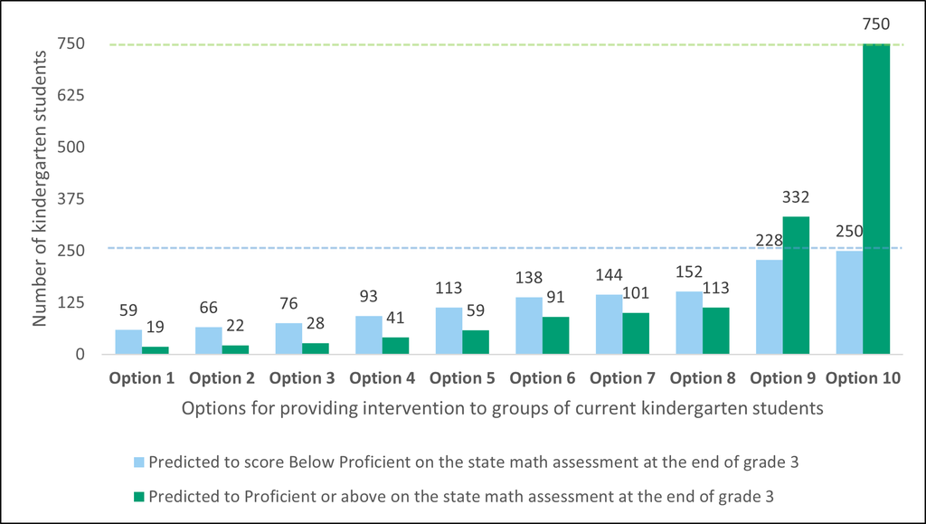

Suppose that after reviewing their options, the educators in Eduphonia choose option 8, in which all groups will receive the intervention except the two with the lowest probabilities for scoring Below Proficient on the state assessment at the end of grade 3. The probability threshold (`pth`) associated with that option is 0.385. Based on the final decision, the data analyst can plot the final decision tree for use in implementing the choice (exhibit 11).

**Exhibit 11. Plot the final decision tree for identifying students for intervention**

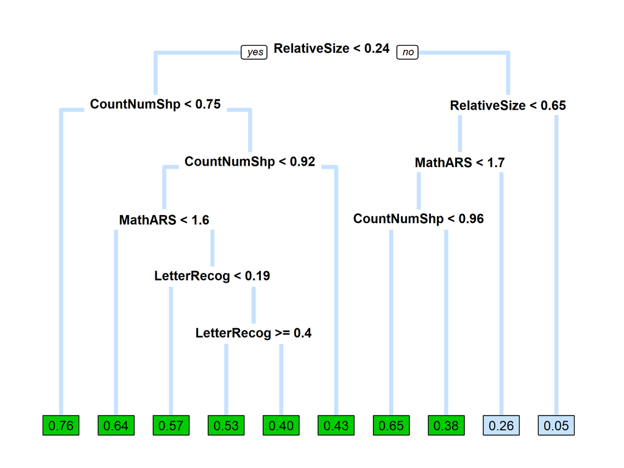

```r
# Use rpart.plot() to plot the final decision tree using the chosen probability threshold.
rpart.plot(
  mytree$finalModel,                        # The optimal model from the CART analysis.
  box.palette = c("slategray1","green3"),   # Green for intervention, blue for not.
  pal.thresh = 0.38,                        # Threshold for determining intervention status.
  type = 0,                                 # Draw labels for each split and node.
  extra = 7,                                # Show predicted probability for the node.
  branch.lwd = 5,                           # Width of branches.
  branch.col = "slategray1",                # Color of the branches.
  leaf.round = 0,                           # Do not use rounded terminal nodes.
  xflip = T,                                # Flip the tree horizontally.
  cex = 1                                   # Size of text.
)
```

Every value above this cutoff is colored green to indicate that students who will receive the intervention, while every value below the cutoff is colored blue to indicate that students who will not receive the intervention. Examining the decision tree in exhibit 11, users can see that the decision rules illustrate that a student will receive the intervention if they have:

- a RelativeSize score of less than 0.24, or
- a RelativeSize score between 0.24 and 0.65 and a MathARS score of less than 1.7.

## Customization

The `rpart` and `caret` packages provide several options for obtaining the optimal model. As data analysts gain more experience with CART and a deeper understanding of the models, they can consider additional ways to customize the training and tuning. This section describes how to create a metric for evaluating and choosing a model and introduces a loss function that can incorporate preferences regarding the relative importance of different types of errors.

Another customization allows the CART analysis algorithm to change how it considers different types of errors. A loss function imposes a penalty on certain types of errors, increasing the cost of making that error when evaluating decision rules using a performance measure and encouraging the model to avoid them. For example, a penalty of 2 on false negatives means that failing to correctly predict that a student will score Below Proficient on the state math assessment at the end of grade 3 is twice as costly as failing to correctly predict a student will score Proficient or above.

**Exhibit 12. CART analysis example with additional customizations**

```r
# Create a performance metric that is the sum of sensitivity and specificity.
mymetric <- function(data, lev = levels(data$obs), model = NULL) {
  out <- c(twoClassSummary(data, lev = levels(data$obs), model = NULL))
  metric <- out["Spec"] + out["Sens"]
  c(out, SS = metric)
}

# Use expand.grid() to create a matrix with penalties ranging from 1 to 8,
# along with columns to collect information on the performance metric and
# complexity parameter.
mygrid <- expand.grid(penalty=seq(1,8,1),ss=0,cp=0)

# Use list() to define a place to store all the models.
models <- list()

# Adjust trainControl() to use the metric above.
mycontrol <- trainControl(
  method = "repeatedcv",
  number = 10,
  repeats = 10,
  savePredictions = "final",
  classProbs = TRUE,
  summaryFunction = mymetric,
  selectionFunction = "oneSE"
)

# There is one row in mygrid for each penalty level. For each penalty level,
# use train() to run the CART analysis model.
for (iteration in 1:nrow(mygrid)) {

  # Store train() results
  models[[iteration]] <- train(
    myformula,
    data = mytrain,
    method = "rpart",
    trControl = mycontrol,
    tuneLength = 25,
    metric = "SS.Spec",

    # Use parms to send the loss parameter to rpart, with the current
    # penalty value for false negatives from this time through the loop.
    parms = list(loss=matrix(c(0,1,mygrid$penalty[iteration],0),byrow=TRUE,nrow=2))
  )

  # Use which.max() to find the model with the highest metric value.
  best <- which.max(models[[iteration]]$results$SS.Spec)

  # Store the values of the metric and the tuning parameter, cp.
  mygrid$ss[iteration] <- models[[iteration]]$results$SS.Spec[best]
  mygrid$cp[iteration] <- models[[iteration]]$results$cp[best]
}

# Use which.max() to select the row with the highest value of the performance
# metric and then extract the model that generated it.
mytree <- models[[which.max(mygrid$ss)]]
```